# `page`

Element

Layouts its child onto one or multiple pages.

Although this function is primarily used in set rules to affect page properties, it can also be used to explicitly render its argument onto a set of pages of its own.

Pages can be set to use `auto` as their width or height. In this case, the pages will grow to fit their content on the respective axis.

The [Guide for Page Setup](https://typst.app/docs/guides/page-setup/) explains how to use this and related functions to set up a document with many examples.

## Example

[output not shown]

## Accessibility

The contents of the page’s header, footer, foreground, and background are invisible to Assistive Technology (AT) like screen readers. Only the body of the page is read by AT. Do not include vital information not included elsewhere in the document in these areas.

## Styling

Note that the `page` element cannot be targeted by show rules; writing `show page: ..` has no effect. To repeat content on every page, you can instead configure the `header`, `footer`, `background`, and `foreground` properties with a set rule.

## Parameters

```
page(
  paper: str,
  width: auto or length,
  height: auto or length,
  flipped: bool,
  margin: auto or relative or dictionary,
  bleed: relative or dictionary,
  binding: auto or alignment,
  columns: int,
  fill: none or auto or color or gradient or tiling,
  numbering: none or str or function,
  supplement: none or auto or content,
  number-align: alignment,
  header: none or auto or content,
  header-ascent: relative,
  footer: none or auto or content,
  footer-descent: relative,
  background: none or content,
  foreground: none or content,
  body: content,
) → content
```

### `paper`

str

Default: `"a4"`

A standard paper size to set width and height.

This is just a shorthand for setting `width` and `height` and, as such, cannot be retrieved in a context expression.

**View options**

| **Variant** | **Details** |
| --- | --- |
| `"a0"` | A paper that is 841.0 × 1189.0 millimeters in size. |
| `"a1"` | A paper that is 594.0 × 841.0 millimeters in size. |
| `"a2"` | A paper that is 420.0 × 594.0 millimeters in size. |
| `"a3"` | A paper that is 297.0 × 420.0 millimeters in size. |
| `"a4"` | A paper that is 210.0 × 297.0 millimeters in size. |
| `"a5"` | A paper that is 148.0 × 210.0 millimeters in size. |
| `"a6"` | A paper that is 105.0 × 148.0 millimeters in size. |
| `"a7"` | A paper that is 74.0 × 105.0 millimeters in size. |
| `"a8"` | A paper that is 52.0 × 74.0 millimeters in size. |
| `"a9"` | A paper that is 37.0 × 52.0 millimeters in size. |
| `"a10"` | A paper that is 26.0 × 37.0 millimeters in size. |
| `"a11"` | A paper that is 18.0 × 26.0 millimeters in size. |
| `"iso-b1"` | A paper that is 707.0 × 1000.0 millimeters in size. |
| `"iso-b2"` | A paper that is 500.0 × 707.0 millimeters in size. |
| `"iso-b3"` | A paper that is 353.0 × 500.0 millimeters in size. |
| `"iso-b4"` | A paper that is 250.0 × 353.0 millimeters in size. |
| `"iso-b5"` | A paper that is 176.0 × 250.0 millimeters in size. |
| `"iso-b6"` | A paper that is 125.0 × 176.0 millimeters in size. |
| `"iso-b7"` | A paper that is 88.0 × 125.0 millimeters in size. |
| `"iso-b8"` | A paper that is 62.0 × 88.0 millimeters in size. |
| `"iso-c3"` | A paper that is 324.0 × 458.0 millimeters in size. |
| `"iso-c4"` | A paper that is 229.0 × 324.0 millimeters in size. |
| `"iso-c5"` | A paper that is 162.0 × 229.0 millimeters in size. |
| `"iso-c6"` | A paper that is 114.0 × 162.0 millimeters in size. |
| `"iso-c7"` | A paper that is 81.0 × 114.0 millimeters in size. |
| `"iso-c8"` | A paper that is 57.0 × 81.0 millimeters in size. |
| `"din-d3"` | A paper that is 272.0 × 385.0 millimeters in size. |
| `"din-d4"` | A paper that is 192.0 × 272.0 millimeters in size. |
| `"din-d5"` | A paper that is 136.0 × 192.0 millimeters in size. |
| `"din-d6"` | A paper that is 96.0 × 136.0 millimeters in size. |

[output cut: 77 more lines]

### `width`

auto or length Settable

Default: `595.28pt`

The width of the final page, after any trims have been applied.

In professional printing setups, this may be smaller than the sheet size fed into the printer.

See the `bleed` parameter for details on how to set a trim or bleed area.

**View example**

[output not shown]

### `height`

auto or length Settable

Default: `841.89pt`

The height of the final page area, after any trims have been applied.

If this is set to `auto`, page breaks can only be triggered manually by inserting a page break or by adding another non-empty page set rule. Most examples throughout this documentation use `auto` for the height of the page to dynamically grow and shrink to fit their content.

### `flipped`

bool Settable

Default: `false`

Whether the page is flipped into landscape orientation.

**View example**

```
#set page(
  "us-business-card",
  flipped: true,
  fill: rgb("f2e5dd"),
)

#set align(bottom + end)
#text(14pt)[*Sam H. Richards*] \
_Procurement Manager_

#set text(10pt)
23 W 23rd Street \
New York, NY 10010 \
+1 (212) 555-0155
```

[figure not shown]

### `margin`

auto or relative or dictionary Settable

Default: `auto`

The page’s margins.

- `auto`: The margins are set automatically to 2.5/21 times the smaller dimension of the page. This results in 2.5 cm margins for an A4 page.
- A single length: The same margin on all sides.
- A dictionary: With a dictionary, the margins can be set individually. The dictionary can contain the following keys in order of precedence:
  - `top`: The top margin.
  - `right`: The right margin.
  - `bottom`: The bottom margin.
  - `left`: The left margin.
  - `inside`: The margin at the inner side of the page (where the binding is).
  - `outside`: The margin at the outer side of the page (opposite to the binding).
  - `x`: The horizontal margins.
  - `y`: The vertical margins.
  - `rest`: The margins on all sides except those for which the dictionary explicitly sets a size.

All keys are optional; omitted keys will use their previously set value, or the default margin if never set. In addition, the values for `left` and `right` are mutually exclusive with the values for `inside` and `outside`. The values should be relative lengths or `auto`.

**View example**

```
#set page(
 width: 3cm,
 height: 4cm,
 margin: (x: 8pt, y: 4pt),
)

#rect(
  width: 100%,
  height: 100%,
  fill: aqua,
)
```

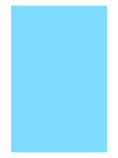

### `bleed`

relative or dictionary Settable

Default: `(:)`

The page’s bleed margin.

The bleed is the area of content that extends beyond the final trimmed size of the page. It ensures that no unprinted edges appear in the final product, even if minor trimming misalignments occur.

Accepted values:

- A single length: The same bleed on all sides.
- A dictionary: With a dictionary, the bleed margins can be set individually. The dictionary may include the following keys, listed in order of precedence:
  - `top`: The top bleed margin.
  - `right`: The right bleed margin.
  - `bottom`: The bottom bleed margin.
  - `left`: The left bleed margin.
  - `inside`: The bleed margin at the inner side of the page (where the binding is).
  - `outside`: The bleed margin at the outer side of the page (opposite to the binding).
  - `x`: The horizontal bleed margins.
  - `y`: The vertical bleed margins.
  - `rest`: The bleed margins on all sides except those for which the dictionary explicitly sets a size.

All keys are optional; omitted keys will use their previously set value, or `0pt` if never set. In addition, the values for `left` and `right` are mutually exclusive with the values for `inside` and `outside`. The values should be relative lengths.

In PDF export, if the bleed is non-zero, a `TrimBox` is defined for the page.

**View example**

```
#set page(
  width: 8cm,
  height: 5cm,
  margin: 1cm,
  // The bleed is not visible in the preview;
  // it exceeds beyond the page.
  bleed: 0.5cm,
  // Fills the entire bleed area, so there will
  // be no white strips after printing and trimming.
  background: rect(width: 100%, height: 100%, fill: aqua),
)

#rect(width: 100%, height: 100%, fill: white)
```

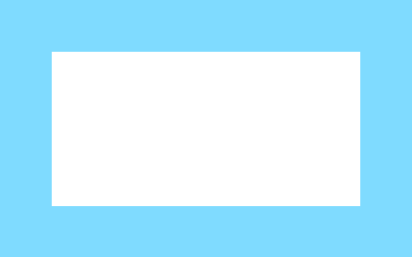

### `binding`

auto or alignment Settable

Default: `auto`

On which side the pages will be bound.

- `auto`: Equivalent to `left` if the text direction is left-to-right and `right` if it is right-to-left.
- `left`: Bound on the left side.
- `right`: Bound on the right side.

This affects the meaning of the `inside` and `outside` options for margins.

### `columns`

int Settable

Default: `1`

How many columns the page has.

If you need to insert columns into a page or other container, you can also use the `columns` function.

```
#set page(columns: 2, height: 4.8cm)
Climate change is one of the most
pressing issues of our time, with
the potential to devastate
communities, ecosystems, and
economies around the world. It's
clear that we need to take urgent
action to reduce our carbon
emissions and mitigate the impacts
of a rapidly changing climate.
```

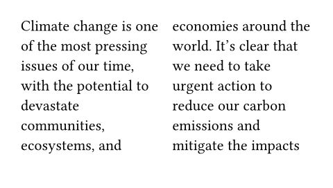

### `fill`

none or auto or color or gradient or tiling Settable

Default: `auto`

The page’s background fill.

Setting this to something non-transparent instructs the printer to color the complete page. If you are considering larger production runs, it may be more environmentally friendly and cost-effective to source pre-dyed pages and not set this property.

When set to `none`, the background becomes transparent. Note that PDF pages will still appear with a (usually white) background in viewers, but they are actually transparent. (If you print them, no color is used for the background.)

The default of `auto` results in `none` for PDF output, and `white` for PNG and SVG.

**View example**

```
#set page(fill: rgb("444352"))
#set text(fill: rgb("fdfdfd"))
*Dark mode enabled.*
```

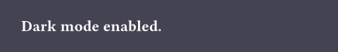

### `numbering`

none or str or function Settable

Default: `none`

How to number the pages. You can refer to the Page Setup Guide for [customizing page numbers](https://typst.app/docs/guides/page-setup/#page-numbers).

Accepts a numbering pattern or function taking one or two numbers:

1. The first number is the current page number.
2. The second number is the total number of pages. In a numbering pattern, the second number can be omitted. If a function is passed, it will receive one argument in the context of links or references, and two arguments when producing the visible page numbers.

These are logical numbers controlled by the page counter, and may thus not match the physical numbers. Specifically, they are the current and the final value of `counter(page)`. See the `counter` documentation for more details.

If an explicit `footer` (or `header` for top-aligned numbering) is given, the numbering is ignored.

**View example**

```
#set page(
  height: 100pt,
  margin: (top: 16pt, bottom: 24pt),
  numbering: "1 / 1",
)

#lorem(48)
```

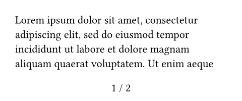

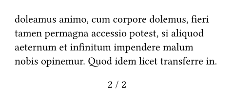

### `supplement`

none or auto or content Settable

Default: `auto`

A supplement for the pages.

For page references, this is added before the page number.

**View example**

```
#set page(numbering: "1.", supplement: [p.])

= Introduction <intro>
We are on #ref(<intro>, form: "page")!
```

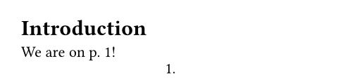

### `number-align`

alignment Settable

Default: `center + bottom`

The alignment of the page numbering.

If the vertical component is `top`, the numbering is placed into the header and if it is `bottom`, it is placed in the footer. Horizon alignment is forbidden. If an explicit matching `header` or `footer` is given, the numbering is ignored.

**View example**

```
#set page(
  margin: (top: 16pt, bottom: 24pt),
  numbering: "1",
  number-align: right,
)

#lorem(30)
```

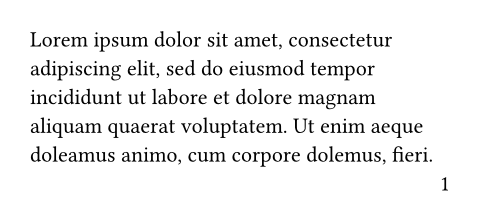

### `header`

none or auto or content Settable

Default: `auto`

The page’s header. Fills the top margin of each page.

- Content: Shows the content as the header.
- `auto`: Shows the page number if a `numbering` is set and `number-align` is `top`.
- `none`: Suppresses the header.

**View example**

```
#set par(justify: true)
#set page(
  margin: (top: 32pt, bottom: 20pt),
  header: [
    #set text(8pt)
    #smallcaps[Typst Academy]
    #h(1fr) _Exercise Sheet 3_
  ],
)

#lorem(19)
```

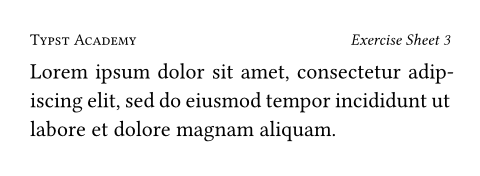

### `header-ascent`

relative Settable

Default: `30% + 0pt`

The amount the header is raised into the top margin. Ratios are relative to the height of the top margin.

### `footer`

none or auto or content Settable

Default: `auto`

The page’s footer. Fills the bottom margin of each page.

- Content: Shows the content as the footer.
- `auto`: Shows the page number if a `numbering` is set and `number-align` is `bottom`.
- `none`: Suppresses the footer.

For just a page number, the `numbering` property typically suffices. If you want to create a custom footer but still display the page number, you can directly access the page counter.

**View example**

```
#set par(justify: true)
#set page(
  height: 100pt,
  margin: 20pt,
  footer: context [
    #set align(right)
    #set text(8pt)
    #counter(page).display(
      "1 of I",
      both: true,
    )
  ]
)

#lorem(48)
```

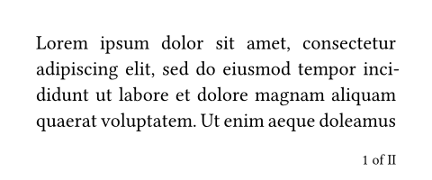

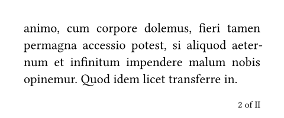

### `footer-descent`

relative Settable

Default: `30% + 0pt`

The amount the footer is lowered into the bottom margin. Ratios are relative to the height of the bottom margin.

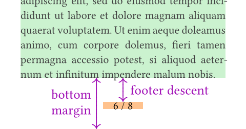

### `background`

none or content Settable

Default: `none`

Content in the page’s background.

This content will be placed behind the page’s body. It can be used to place a background image or a watermark.

For convenience, relative lengths are resolved against the page size including the page `bleed` when used in background content. For example, on a page that is `100mm` wide with a `5mm` bleed, a width of `100%` is computed as `5mm + 100mm + 5mm`.

**View example**

```
#set page(background: rotate(24deg,
  text(18pt, fill: rgb("FFCBC4"))[
    *CONFIDENTIAL*
  ]
))

= Typst's secret plans
In the year 2023, we plan to take
over the world (of typesetting).
```

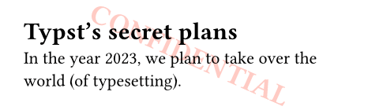

### `foreground`

none or content Settable

Default: `none`

Content in the page’s foreground.

This content will overlay the page’s body.

Relative lengths are resolved against the page size including `bleed`, following the same behavior as `background`.

**View example**

```
#set page(foreground: text(24pt)[🤓])

Reviewer 2 has marked our paper
"Weak Reject" because they did
not understand our approach...
```

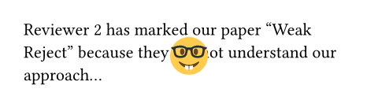

### `body`

content

Default: `[]`

The contents of the page(s).

Multiple pages will be created if the content does not fit on a single page. A new page with the page properties prior to the function invocation will be created after the body has been typeset.

© Typst GmbH and contributors  
Licensed under the Apache License, Version 2.0.  
https://typst.app/docs/reference/layout/page/